# Shares analysis

C-dog & Kray-Kray

October 15, 2021

Libraries

```r
library("tidyverse")
library("GGally")
library("caret")
set.seed(1234)
```

```r
page_name <- if_else(params$data == 1, "Business",
if_else(params$data == 2, "Lifestyle",
if_else(params$data == 3, "Entertainment",
if_else(params$data == 4, "Social Media",
if_else(params$data == 5, "Technology", "World")))))
```

Analysis of Business shares.

Read in and subset the data

```r
news <- read_csv("OnlineNewsPopularity.csv")

news2 <- news %>%  mutate(type =
            if_else(data_channel_is_bus == 1, 1,
            if_else( data_channel_is_lifestyle == 1, 2,
            if_else(data_channel_is_entertainment == 1 , 3,
            if_else(data_channel_is_socmed == 1,  4 ,
            if_else(data_channel_is_tech == 1, 5, 6))))))


business <- news %>% filter(data_channel_is_bus == 1)
lifestyle <- news %>% filter(data_channel_is_lifestyle == 1)
entertainment <- news %>% filter(data_channel_is_entertainment == 1)
socmed <- news %>% filter(data_channel_is_socmed == 1)
tech <- news %>% filter(data_channel_is_tech == 1)
world <- news %>% filter(data_channel_is_world == 1)



# The sum of these rows does not equal the total number of rows in news.

# Check if there are unclassified observations
other <- news %>% filter((data_channel_is_lifestyle + data_channel_is_entertainment + data_channel_is_lifestyle + data_channel_is_bus + data_channel_is_socmed + data_channel_is_tech + data_channel_is_world) == 0)

# This accounts for all of the data. Life is good.
```

Now that we had an excellent partitioning of the data. By going to the website and reading the descriptions of the variables, we became interested to see if there was a time influence on the number of shares. If an article was published on a week day versus a weekend, would it get more shares? We thought so, with an intuition that people read more articles at work, and thus would be more likely to share articles that publish during the work week. Let's see if we were on to something, shall we...

Set the Channel

```r
channel <-  news2 %>% filter(type == params$data)
channel
```

```
## # A tibble: 6,258 x 62
##    url                 timedelta n_tokens_title n_tokens_content n_unique_tokens
##    <chr>                   <dbl>          <dbl>            <dbl>           <dbl>
##  1 http://mashable.co~       731              9              255           0.605
##  2 http://mashable.co~       731              9              211           0.575
##  3 http://mashable.co~       731              8              397           0.625
##  4 http://mashable.co~       731             13              244           0.560
##  5 http://mashable.co~       731             11              723           0.491
##  6 http://mashable.co~       731              8              708           0.482
##  7 http://mashable.co~       731             10              142           0.655
##  8 http://mashable.co~       731             12              444           0.601
##  9 http://mashable.co~       731              6              109           0.667
## 10 http://mashable.co~       730             13              306           0.535
## # ... with 6,248 more rows, and 57 more variables: n_non_stop_words <dbl>,
## #   n_non_stop_unique_tokens <dbl>, num_hrefs <dbl>, num_self_hrefs <dbl>,
## #   num_imgs <dbl>, num_videos <dbl>, average_token_length <dbl>,
## #   num_keywords <dbl>, data_channel_is_lifestyle <dbl>,
## #   data_channel_is_entertainment <dbl>, data_channel_is_bus <dbl>,
## #   data_channel_is_socmed <dbl>, data_channel_is_tech <dbl>,
## #   data_channel_is_world <dbl>, kw_min_min <dbl>, kw_max_min <dbl>, ...
```

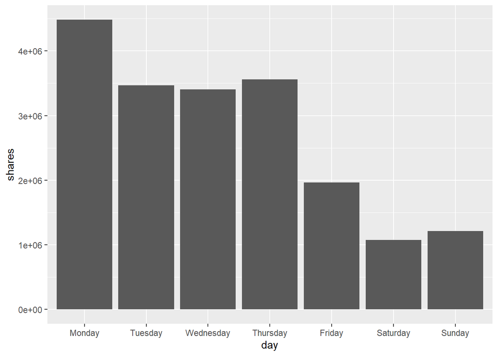

```r
channel <- channel %>% mutate(day =
            if_else(weekday_is_monday == 1, 'Monday',
            if_else( weekday_is_tuesday == 1, 'Tuesday',
            if_else(weekday_is_wednesday == 1 , 'Wednesday',
            if_else( weekday_is_thursday == 1 ,  'Thursday' ,
            if_else(weekday_is_friday == 1, 'Friday',
            if_else(weekday_is_saturday == 1, 'Saturday', 'Sunday')))))))

channel$day <- factor(channel$day, levels = c("Monday", "Tuesday", "Wednesday", "Thursday", "Friday", "Saturday", "Sunday"))
ggplot(data=channel, aes(x=day, y=shares)) +
  geom_col()
```

This graph indicates which day has the most shares. A higher bar indicates more shares on that day.

```r
channel %>% group_by(day) %>% summarise(Total = sum(shares), mean = mean(shares), sd = sd(shares))
```

```
## # A tibble: 7 x 4
##   day         Total  mean     sd
##   <fct>       <dbl> <dbl>  <dbl>
## 1 Monday    4482214 3887. 28313.
## 2 Tuesday   3466021 2932. 10827.
## 3 Wednesday 3401897 2677.  8160.
## 4 Thursday  3560327 2885. 13138.
## 5 Friday    1966657 2364.  5134.
## 6 Saturday  1075736 4427. 10139.
## 7 Sunday    1215518 3544.  4979.
```

```r
# Creating 'workweek' variable for modeling (Mon - Thurs VS Fri - Sun):

channel <- channel %>% mutate(workweek =
            if_else(weekday_is_monday == 1 | weekday_is_tuesday == 1 |
                      weekday_is_wednesday == 1 |  weekday_is_thursday == 1, 'yes', 'no'))
```

The summary statistics indicate the total number of shares per day along with the average and stanard deviation. Days with the highest mean indicate more shares. A large standard deviation indicates high variability in the number of shares on that day.

Multi media

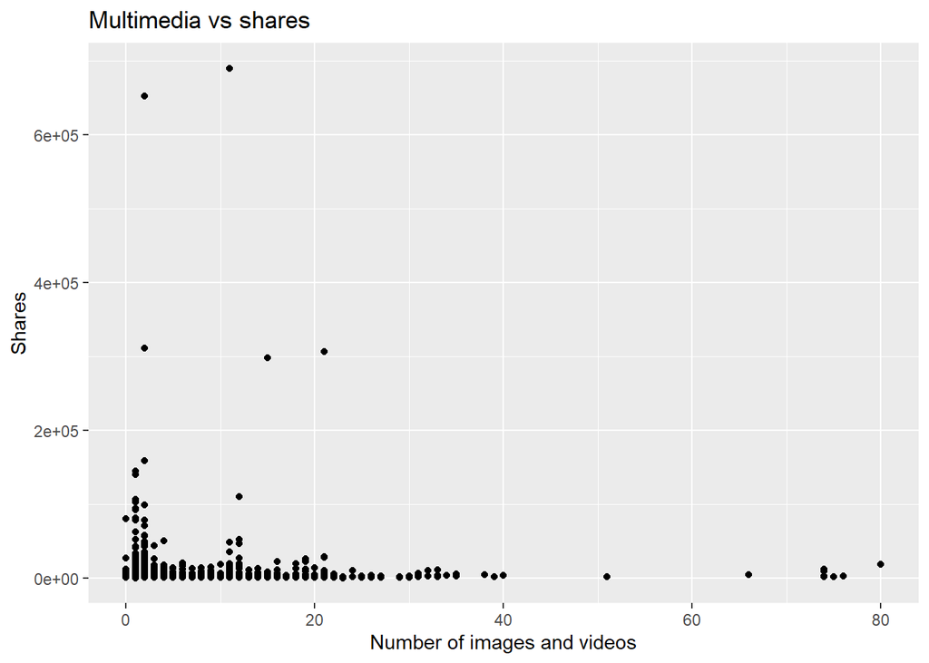

```r
# Make a new variable combining images and videos
channel <- channel %>% mutate(multimedia = num_imgs + num_videos)
channel <- channel %>% mutate(multimedia_category =
                                  if_else(multimedia >= 30, "high",
                                  if_else(multimedia >= 20, "medium",
                                  if_else(multimedia >= 10, "low", "very low"))))
channel$multimedia_category <- factor(channel$multimedia_category, levels = c("very low", "low", "medium", "high"))

ggplot(data = channel, aes(x= multimedia, y=shares)) +
  geom_point() +
  labs(x="Number of images and videos", y= "Shares", title = "Multimedia vs shares")
```

This graph displays the number of images and videos against the number of shares. A positive trend would indicate that more images and videos are associatied with more shares. A negative trend would indicate that more images and videos are associated with fewer shares.

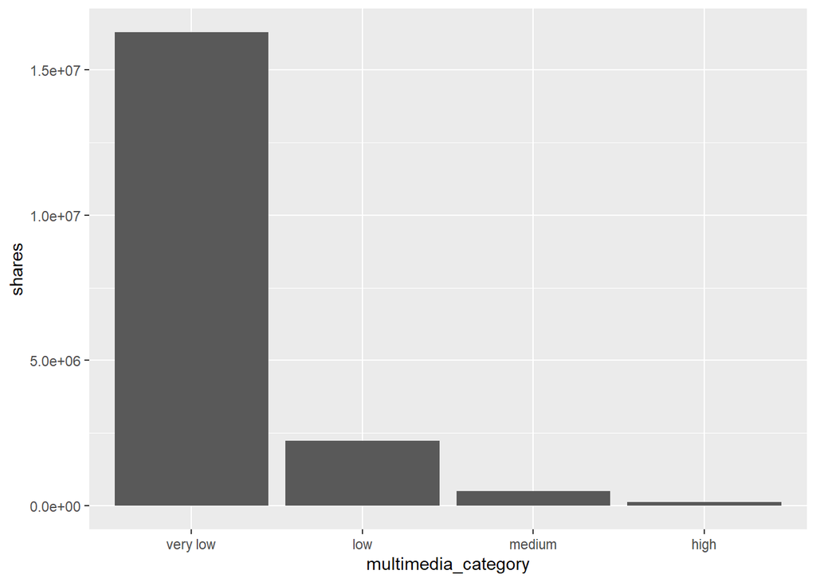

```r
ggplot(data=channel, aes(x=multimedia_category, y=shares)) +
  geom_col()
```

How long is the article

With today's shortened attention span, are shorter articles more likely to be shared?

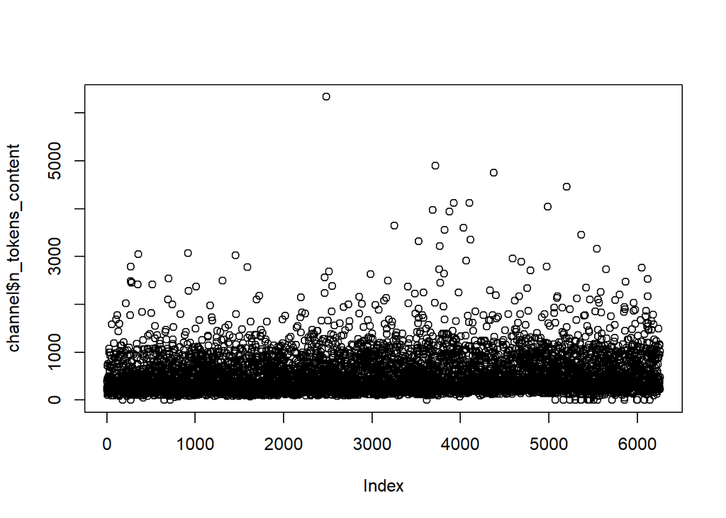

```r
# First, what is the distribution of article length?
plot(channel$n_tokens_content)
```

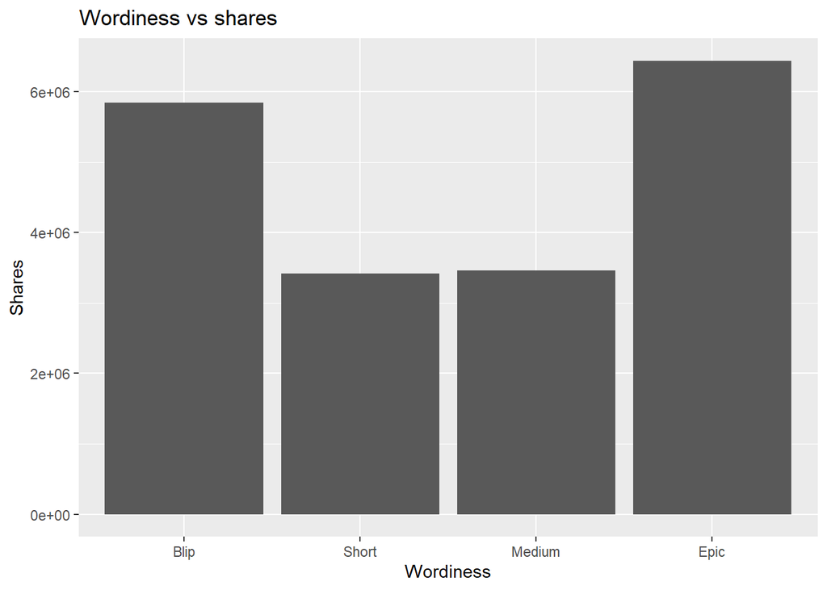

```r
results <- summary(news$n_tokens_content)

# Looks like the vast majority are 1000 words or less.  So we'll break them into quantiles: Blip, Short, Medium, Epic

channel <- channel %>% mutate(wordiness = if_else(n_tokens_content > results[[5]], 'Epic', if_else(n_tokens_content >results[[3]], 'Medium', if_else(n_tokens_content > results[[2]], 'Short', 'Blip'))))

channel$wordiness <- factor(channel$wordiness, levels = c("Blip", "Short", "Medium", "Epic"))

ggplot(data = channel, aes(x = wordiness, y=shares)) +
  geom_col() +
  labs(x="Wordiness", y= "Shares", title = "Wordiness vs shares")
```

```r
# Summary of wordiness

channel %>% group_by(wordiness) %>% summarise(Total = sum(shares), mean = mean(shares), sd = sd(shares))
```

```
## # A tibble: 4 x 4
##   wordiness   Total  mean     sd
##   <fct>       <dbl> <dbl>  <dbl>
## 1 Blip      5843010 3654. 20904.
## 2 Short     3419600 2135.  4267.
## 3 Medium    3464341 2378.  5874.
## 4 Epic      6441419 4026. 19924.
```

The category with the highest bar indicates which grouping of lengths was most shared for this category of articles.

The summary statistics show the total number of shares based on article length. It also reports the average and the standard deviation. If the standard deviation is high, then it says there's much more variation in the number of shares.

How long is the title? Is the title one word or a phrase? Does length perhaps grab the readers attention to read it and then to pass it on...let's look and see.

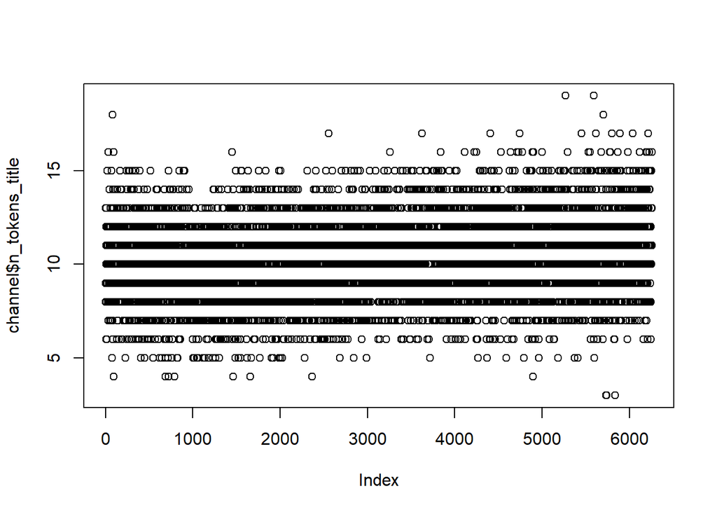

```r
# First, what is the distribution of title length?
plot(channel$n_tokens_title)
```

```r
results <- summary(news$n_tokens_title)
results
```

```
##    Min. 1st Qu.  Median    Mean 3rd Qu.    Max.
##     2.0     9.0    10.0    10.4    12.0    23.0
```

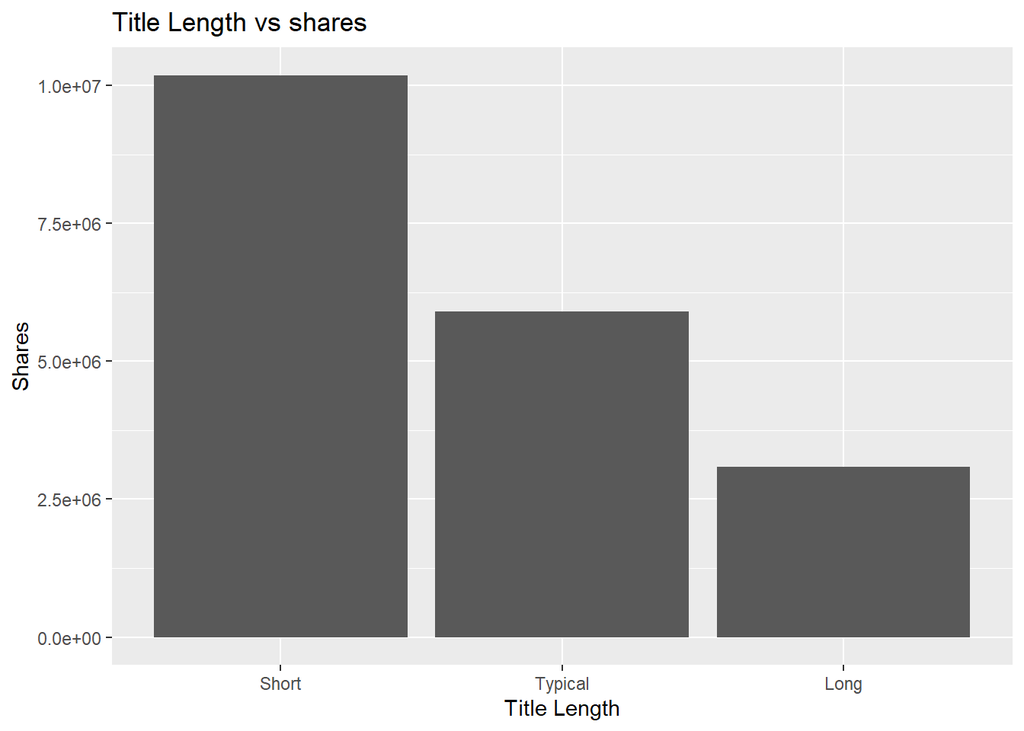

```r
# Good God!  A title 23 words long???  Isn't that a sentence and not a title???
# Well, let's grouping by quartiles:

channel <- channel %>% mutate(title_words =
            if_else(n_tokens_title > results[[5]] , 'Long',
                    if_else(n_tokens_title > results[[3]], 'Typical', 'Short')))


channel$title_words <- factor(channel$title_words,
                               levels = c("Short", "Typical", "Long"))

ggplot(data = channel, aes(x = title_words, y = shares)) +
  geom_col() +
  labs(x="Title Length", y= "Shares", title = "Title Length vs shares")
```

The category with the highest bar indicates the length that is most shared.

Would a long article have a long title? Is there a relationship between article length and title length? If so, there might be an issue of correlation.

```r
table(channel$wordiness, channel$title_words)
```

```
##
##          Short Typical Long
##   Blip     858     477  264
##   Short    861     498  243
##   Medium   765     470  222
##   Epic     928     457  215
```

Is it a positive article, or negative?

This table compares the average number of shares based on positive and negative polarity of an article. If it is more positive than negative it is classified as positive, if not, negative. The summary statistics indicate the mean number of shares for articles classified as negative or positive and the standard deviation. A higher mean value would indicate more shares.

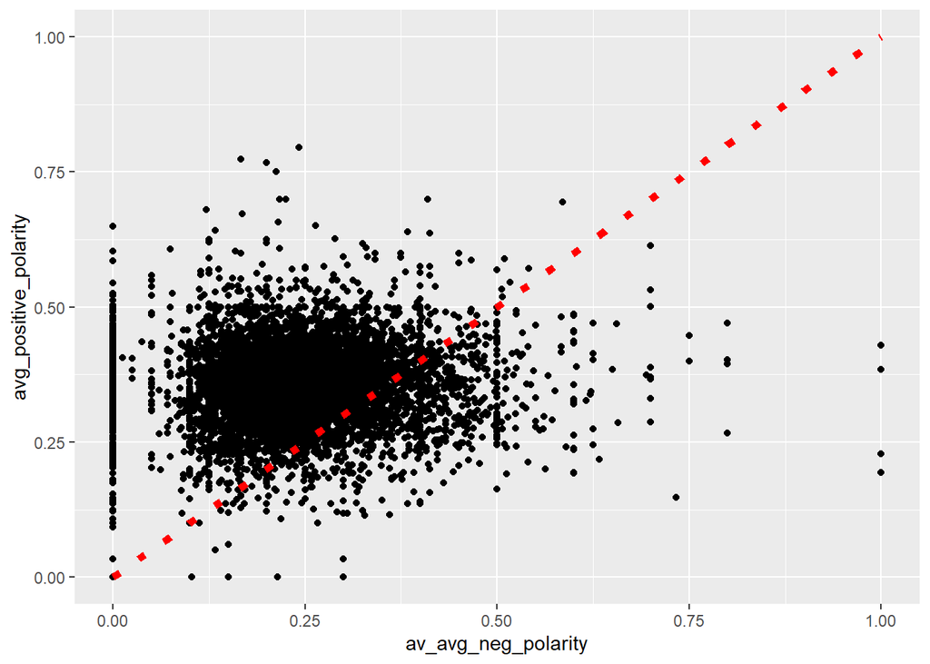

```r
channel <- channel %>% mutate(av_avg_neg_polarity = -1*avg_negative_polarity)
ggplot(data=channel, aes(x=av_avg_neg_polarity, y=avg_positive_polarity)) +
  geom_point() +
  stat_function(fun=function(x) x, size = 2, lty = 3 ,color = 'red')
```

This graph shows the relationship between the positive and negative polarity of an article. Values above the line y=x would indicate more positive and values below the line y=x indicate more negativity.

```r
channel <- channel %>% mutate( sentiment = if_else(avg_positive_polarity > av_avg_neg_polarity, "positive", "negative"))

channel %>% group_by(sentiment) %>% summarise(mean = mean(shares), sd= sd(shares), sum = sum(shares), ratio = sum(shares))
```

```
## # A tibble: 2 x 5
##   sentiment  mean     sd      sum    ratio
##   <chr>     <dbl>  <dbl>    <dbl>    <dbl>
## 1 negative  3814. 22669.  4065841  4065841
## 2 positive  2909. 12935. 15102529 15102529
```

```r
summary(news$shares)
```

```
##    Min. 1st Qu.  Median    Mean 3rd Qu.    Max.
##       1     946    1400    3395    2800  843300
```

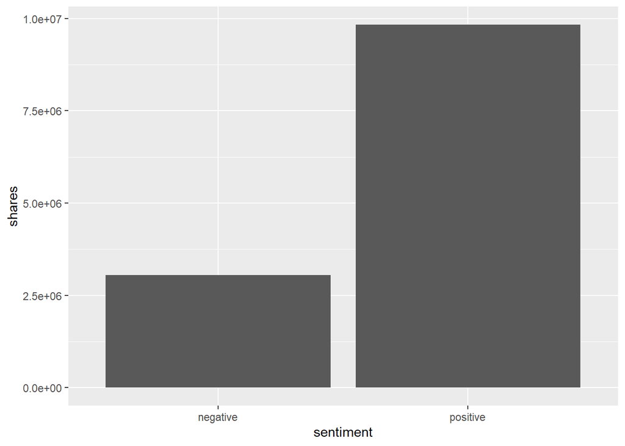

```r
channel2 <- channel %>% subset(shares >= 2800)

ggplot(data = channel2, aes(x=sentiment, y=shares)) +
  geom_col()
```

This graph took the 25% of articles with the most shares and display the shares based on their positivity or negativity. The higher bar will indicate what the most shared articles can be categorized as that sentiment.

Is the title subjective? Do shares lean towards opinion over objectiveness? We would venture yes!

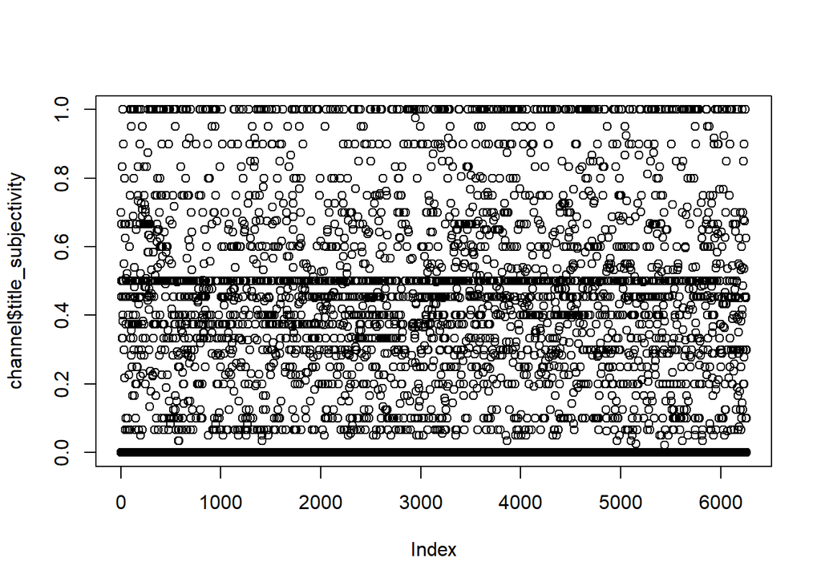

```r
plot(channel$title_subjectivity)
```

```r
head(channel$title_subjectivity)
```

```
## [1] 0.0 0.0 0.0 0.7 0.5 0.0
```

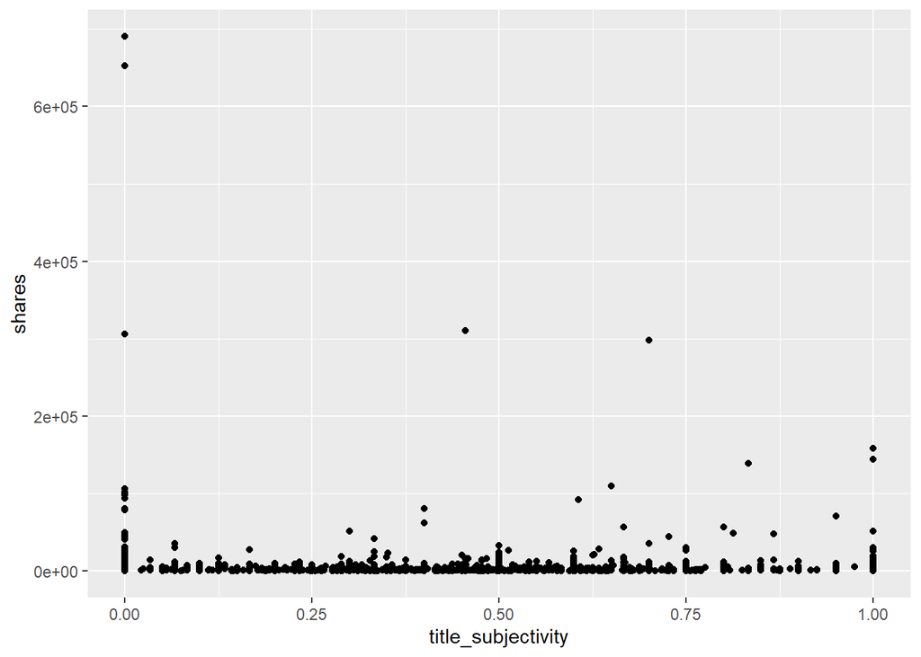

```r
# Looks like the data is a ranking 0 to 1, and is continuous.  Scatterplot time! :)

g2 <- ggplot(channel, aes(x = title_subjectivity, y = shares))
g2 + geom_point()
```

```r
channel <- channel %>% mutate(subjectivity = if_else(title_subjectivity <=.3, "No Subjectivity", if_else(title_subjectivity <= .7, "Somewhat Subjective", "Very Subjective")))


#### ISSUE  ggplot(data=business2, aes(x=subjectivity, y=shares)) +   geom_col()
```